# Calibration

The code below shows you what your “current directory” is. This the folder that R is working from.

```r
getwd()
```

```
[1] "/Users/mb312/dev_trees/excel-but-simpler"
```

Use the “Session” menu in R Studio, and select “Set Working Directory” to navigate to the folder that contains the data for the workshop. This folder should contain files that include `calibration.csv`. When you’ve done that, execute the chunk above to confirm the folder is what you expected.

The first thing we need to do, it so load the various `tidyverse` packages. We do this with the R `library` command. `library` loads code packages so that we can use commands from those packages in our R session:

```r
library('tidyverse')
```

Let’s load the data first:

```r
calibration = read_csv('calibration.csv')
calibration
```

| BSA | Absorbance |
| --- | --- |
| 0 | 0.000 |
| 1 | 0.006 |
| 2 | 0.012 |
| 5 | 0.030 |
| 10 | 0.060 |
| 20 | 0.120 |
| 30 | 0.180 |
| 40 | 0.240 |
| 50 | 0.300 |

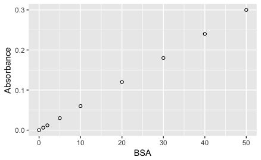

```r
ggplot(calibration, aes(x=BSA, y=Absorbance)) +
    geom_point(shape=1)      # Use hollow circles
```

We would also like to see a regression line through these points. We do this by adding a `lm` (Linear Model) component to the plot, like this:

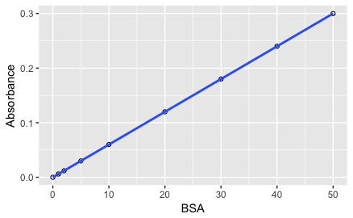

```r
ggplot(calibration, aes(x=BSA, y=Absorbance)) +
    geom_point(shape=1) +    # Use hollow circles
    geom_smooth(method=lm)   # linear model regression line
```

What is the formula for this line? We can show this (the least squares regression line) by estimating it again using R’s `lm` command (Linear Model again):

```r
fit = lm(Absorbance ~ BSA, data=calibration)
summary(fit)
```

```
essentially perfect fit: summary may be unreliable
```

```
Call:
lm(formula = Absorbance ~ BSA, data = calibration)

Residuals:
       Min         1Q     Median         3Q        Max
-3.348e-17 -1.118e-17 -7.213e-18  5.671e-18  5.574e-17

Coefficients:
             Estimate Std. Error   t value Pr(>|t|)
(Intercept) 1.850e-17  1.227e-17 1.508e+00    0.175
BSA         6.000e-03  4.952e-19 1.212e+16   <2e-16 ***
---
Signif. codes:
0 ‘***’ 0.001 ‘**’ 0.01 ‘*’ 0.05 ‘.’ 0.1 ‘ ’ 1

Residual standard error: 2.6e-17 on 7 degrees of freedom
Multiple R-squared:      1, Adjusted R-squared:      1
F-statistic: 1.468e+32 on 1 and 7 DF,  p-value: < 2.2e-16
```

Notice the Intercept and BSA slope in the `Estimate` column above.

So far we have the line for predicting `Absorbance` from `BSA` - but it’s a simple switch to predict `BSA` from `Absorbance`:

```r
reverse_fit = lm(BSA ~ Absorbance, data=calibration)
summary(reverse_fit)
```

```
essentially perfect fit: summary may be unreliable
```

```
Call:
lm(formula = BSA ~ Absorbance, data = calibration)

Residuals:
       Min         1Q     Median         3Q        Max
-6.646e-15 -2.927e-15 -2.687e-15  1.480e-15  1.645e-14

Coefficients:
             Estimate Std. Error   t value Pr(>|t|)
(Intercept) 7.105e-15  3.382e-15 2.101e+00   0.0738 .
Absorbance  1.667e+02  2.274e-14 7.330e+15   <2e-16 ***
---
Signif. codes:
0 ‘***’ 0.001 ‘**’ 0.01 ‘*’ 0.05 ‘.’ 0.1 ‘ ’ 1

Residual standard error: 7.163e-15 on 7 degrees of freedom
Multiple R-squared:      1, Adjusted R-squared:      1
F-statistic: 5.372e+31 on 1 and 7 DF,  p-value: < 2.2e-16
```

What it the relationship between the estimate of slope for this line, and the estimate for the `Absorbance ~ BSA` line?

We can use this fit to predict `BSA` from other values of `Absorbance`. To do this, we make a new data table with the `Absorbance` values to predict for. The `tibble` function makes a new data table. We pass it the name of the new column - in our case, `Absorbance`:

```r
new_absorbance = tibble(Absorbance=c(0.25, 0.04, 0.4))
new_absorbance
```

| Absorbance |
| --- |
| 0.25 |
| 0.04 |
| 0.40 |

Now we can predict `BSA` values from the new `Absorbance` values:

```r
predict(reverse_fit, new_absorbance)
```

```
        1         2         3
41.666667  6.666667 66.666667
```